# HW7_Habilainen

Regina Habilainen

16.11.2022

## Homework Assignment 7

Download the `gapminder` dataset into `R Markdown` session.

1. Perform quick EDA and pick up two variables you want to explore in more depth (for example, life expectancy and gdp) and a subset of data set (for instance, only certain continents, or countries, etc).

EDA: 1. Are there any null values? No. 2. How many observations? 1704.

2. Prepare the data set that includes only variables of your interest in a suitable format for analysis (use `dplyr` package and `tidyr` when necessary).
3. Explore two variables and how they are associated with each other (correlation analysis).
- Is the co-variation linear? No.
- Are the data from each of the 2 variables (x, y) follow a normal distribution (visual inspection of the data normality using histograms)? No. Life expectancy is negatively skewed and population positively skewed.

```r
print(data)
```

```
## # A tibble: 1,704 × 3
## # Groups:   pop [1,704]
##    lifeExp   pop continent
##      <dbl> <int> <fct>
##  1    46.5 60011 Africa
##  2    48.9 61325 Africa
##  3    34.8 63149 Africa
##  4    51.9 65345 Africa
##  5    54.4 70787 Africa
##  6    37.3 71851 Africa
##  7    56.5 76595 Africa
##  8    58.6 86796 Africa
##  9    39.7 89898 Africa
## 10    60.4 98593 Africa
## # … with 1,694 more rows
```

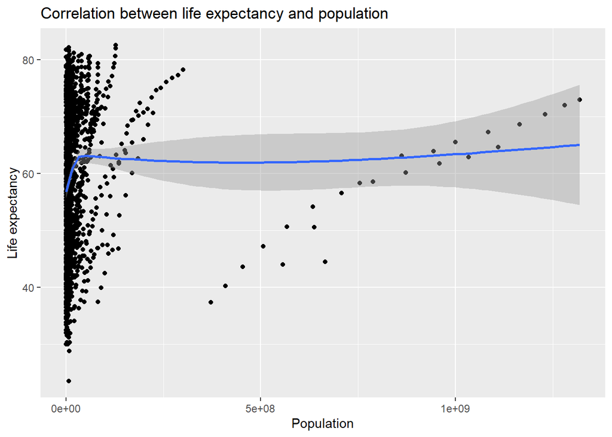

```r
library(ggplot2)
ggplot(data, aes(x=pop, y=lifeExp)) +
  geom_point() +
  labs(x="Population", y="Life expectancy", title="Correlation between life expectancy and population") +
  geom_smooth()
```

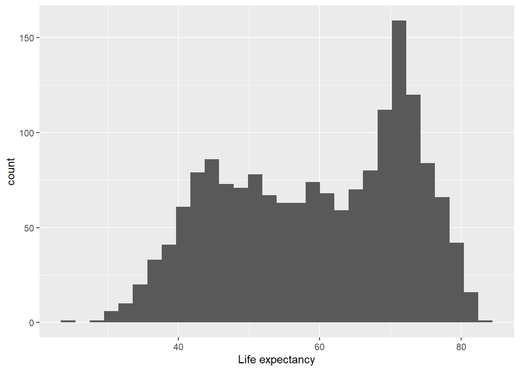

```r
ggplot(data, aes(x=lifeExp)) +
  geom_histogram() +
  labs(x="Life expectancy")
```

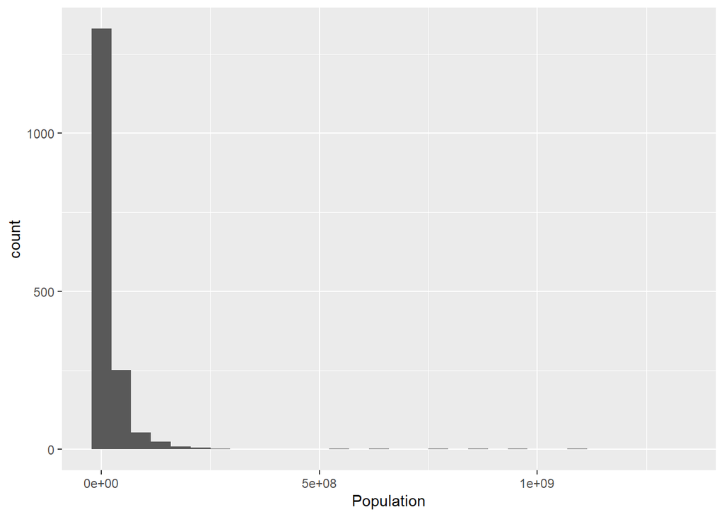

```r
ggplot(data, aes(x=pop)) +
  geom_histogram() +
  labs(x="Population")
```

3.2 Calculate correlation coefficient and provide your interpretation.

```r
cor.test(data$pop, data$lifeExp, method = "spearman")
```

```
##
##  Spearman's rank correlation rho
##
## data:  data$pop and data$lifeExp
## S = 675689264, p-value = 5.825e-14
## alternative hypothesis: true rho is not equal to 0
## sample estimates:
##       rho
## 0.1806119
```

4. Hypothesis testing.  
   4.1 State the null hypothesis and the alternative hypothesis.  
   4.2 Report on collected data and sample size.  
   4.3 Perform Pearson correlation test between two variables.

```r
cor.test(data$pop, data$lifeExp, method = "pearson")
```

```
##
##  Pearson's product-moment correlation
##
## data:  data$pop and data$lifeExp
## t = 2.6854, df = 1702, p-value = 0.007314
## alternative hypothesis: true correlation is not equal to 0
## 95 percent confidence interval:
##  0.01752303 0.11209600
## sample estimates:
##        cor
## 0.06495537
```

4.4 Decide whether to reject or fail to reject your null hypothesis, report selected significance level.  
4.5 Interpret and report the results.

5. Create a report in `R Markdown` with the following sections:
- Introduction (brief description of the data set and variables)
- Description of data transformation
- Correlation analysis (steps for visualisation, checking assumption for correlation analysis, interpretation of correlation coefficient)
- Hypothesis testing: using the Pearson r statistic to conduct hypothesis tests about population correlation values
- Reporting the results

### Introduction

‘Gapminder’ is a dataset with variables like life expectancy, population, and GDP from the years 1952-2007 in different countries of different continents. I chose to explore life expectancy and population in different continents.

### Correlation analysis

In correlation analysis we are trying to see if there is a relationship between two variables. For that two hypotheses were set:

H0 = There is no linear relationship between population and life expectancy.

H1 = There is a linear relationship between population and life expectancy.

Scatter plots are often used to visualize correlation, which can be created with ggplot2 package, using the geom_point() function. We can add regression line with geom_smooth().

Spearman’s correlation analysis would be more fitting as it will give a correlation regardless of skewness. The p-value is 5.825e-14, which is p<0.05, meaning the relationship between the two variables is significant. Correlation 0.1806119 means that it is positive.

With these results the null hypothesis can be rejected.